# Neural Network in Python - Bank Customer Churn model

### Objective

To develop a model/method for identifying customers who are likely to exit

### Background:

Bank customer churn, also known as customer attrition, refers to the phenomenon where customers stop doing business with a bank or switch to another bank. Churn is a critical metric for banks as it directly impacts their customer base and revenue. The dataset represents bank customer information for churn analysis. Each row in the dataset corresponds to a specific customer and contains several features or attributes that describe them.  
While we have worked with BLR, Naive Bayes, SVM and Tree methods in earlier case studies, we will be using Artificial Neural Network method in this case study.

### Import libraries

```python
import os
import pandas as pd
from sklearn.preprocessing import MinMaxScaler
import numpy as np
from sklearn.neural_network import MLPClassifier
from sklearn.model_selection import train_test_split
import matplotlib.pyplot as plt
from sklearn.metrics import roc_curve, auc
from sklearn.metrics import classification_report
import random
```

### Data description

```
+----+-----------------+--------------------------------------------------------+
|    |  Variable Name  |                      Description                       |
+----+-----------------+--------------------------------------------------------+
| 0  |   CustomerId    |                  Customer identifiers                  |
| 1  |     Surname     |                  Surname of Customer                   |
| 2  |   CreditScore   |          Creditworthiness score of customers           |
| 3  |    Geography    |                      Country name                      |
| 4  |     Gender      |                   Gender of customer                   |
| 5  |       Age       |                    Age of customer                     |
| 6  |     Tenure      |     Duration of customer engagement or membership      |
| 7  |     Balance     |       Amount of funds held in customer accounts        |
| 8  |  NumOfProducts  |   Number of products or services owned by customers    |
| 9  |    HasCrCard    |     Whether customers possess a credit card or not     |
| 10 | IsActiveMember  | Whether customers are active member of loyalty program |
| 11 | EstimatedSalary |          The approximate salary of customers           |
| 12 |     Exited      |  Whether customers have churned or exited the service  |
+----+-----------------+--------------------------------------------------------+
```

### Import data

```python
data = pd.read_csv("Bank Churn.csv")
data.head()
```

|  | RowNumber | CustomerId | Surname | CreditScore | Geography | Gender | Age | Tenure | Balance | NumOfProducts | HasCrCard | IsActiveMember | EstimatedSalary | Exited |
| --- | --- | --- | --- | --- | --- | --- | --- | --- | --- | --- | --- | --- | --- | --- |
| 0 | 1 | 15634602 | Hargrave | 619 | France | Female | 42 | 2 | 0.00 | 1 | 1 | 1 | 101348.88 | 1 |
| 1 | 2 | 15647311 | Hill | 608 | Spain | Female | 41 | 1 | 83807.86 | 1 | 0 | 1 | 112542.58 | 0 |
| 2 | 3 | 15619304 | Onio | 502 | France | Female | 42 | 8 | 159660.80 | 3 | 1 | 0 | 113931.57 | 1 |
| 3 | 4 | 15701354 | Boni | 699 | France | Female | 39 | 1 | 0.00 | 2 | 0 | 0 | 93826.63 | 0 |
| 4 | 5 | 15737888 | Mitchell | 850 | Spain | Female | 43 | 2 | 125510.82 | 1 | 1 | 1 | 79084.10 | 0 |

### Data pre-processing

```python
# Creating dummy variables
data = pd.get_dummies(data, columns=["Geography", "Gender"], drop_first=True,dtype = int)

# Scaling
scaler = MinMaxScaler()
data['Age']=scaler.fit_transform(np.array(data['Age']).reshape(-1, 1))
data['Tenure']=scaler.fit_transform(np.array(data['Tenure']).reshape(-1, 1))
data['NumOfProducts']=scaler.fit_transform(np.array(data['NumOfProducts']).reshape(-1, 1))
data['EstimatedSalary']=scaler.fit_transform(np.array(data['EstimatedSalary']).reshape(-1, 1))
data['CreditScore']=scaler.fit_transform(np.array(data['CreditScore']).reshape(-1, 1))
data['Balance']=scaler.fit_transform(np.array(data['Balance']).reshape(-1, 1))
data.head()
```

|  | RowNumber | CustomerId | Surname | CreditScore | Age | Tenure | Balance | NumOfProducts | HasCrCard | IsActiveMember | EstimatedSalary | Exited | Geography_Germany | Geography_Spain | Gender_Male |
| --- | --- | --- | --- | --- | --- | --- | --- | --- | --- | --- | --- | --- | --- | --- | --- |
| 0 | 1 | 15634602 | Hargrave | 0.538 | 0.324324 | 0.2 | 0.000000 | 0.000000 | 1 | 1 | 0.506735 | 1 | 0 | 0 | 0 |
| 1 | 2 | 15647311 | Hill | 0.516 | 0.310811 | 0.1 | 0.334031 | 0.000000 | 0 | 1 | 0.562709 | 0 | 0 | 1 | 0 |
| 2 | 3 | 15619304 | Onio | 0.304 | 0.324324 | 0.8 | 0.636357 | 0.666667 | 1 | 0 | 0.569654 | 1 | 0 | 0 | 0 |
| 3 | 4 | 15701354 | Boni | 0.698 | 0.283784 | 0.1 | 0.000000 | 0.333333 | 0 | 0 | 0.469120 | 0 | 0 | 0 | 0 |
| 4 | 5 | 15737888 | Mitchell | 1.000 | 0.337838 | 0.2 | 0.500246 | 0.000000 | 1 | 1 | 0.395400 | 0 | 0 | 1 | 0 |

### Splitting data into Train and Test data sets

```python
random.seed(14062024)

data1 = data.copy()

# Drop specified columns: 'RowNumber', 'CustomerId', 'Surname'
columns_to_drop = ['RowNumber', 'CustomerId', 'Surname']
data1.drop(columns_to_drop, axis=1, inplace=True)

X = data1.loc[:,data1.columns != 'Exited']
y = data1.loc[:, 'Exited']

X_train, X_test, y_train, y_test = train_test_split(X, y,
                                                   test_size=0.30,
                                                   random_state = 999)
```

### Building model

```python
classifier = MLPClassifier(hidden_layer_sizes=(2), max_iter=1000,
                           activation = 'logistic',solver='adam',random_state=1)

classifier.fit(X_train, y_train)
```

```
MLPClassifier(activation='logistic', hidden_layer_sizes=2, max_iter=1000,
              random_state=1)
```

### ROC Curve and AUC for Train Data

```python
# Get the predicted probabilities for the training data
y_train_prob = classifier.predict_proba(X_train)[:, 1]

# Compute ROC curve and ROC area for the training data
fpr_train, tpr_train, _ = roc_curve(y_train, y_train_prob)
roc_auc_train = auc(fpr_train, tpr_train)
```

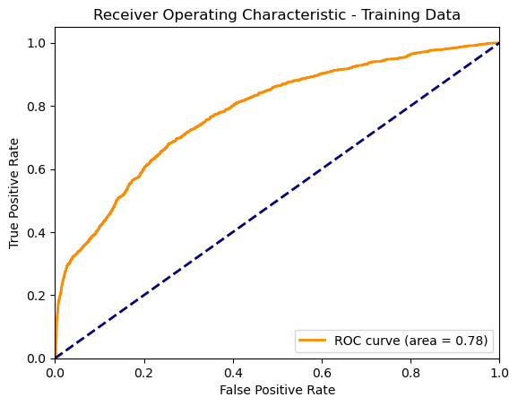

```python
# Plotting the ROC curve for the training data
plt.figure()
plt.plot(fpr_train, tpr_train, color='darkorange', lw=2,
         label='ROC curve (area = %0.2f)' % roc_auc_train)
plt.plot([0, 1], [0, 1], color='navy', lw=2, linestyle='--')
plt.xlim([0.0, 1.0])
plt.ylim([0.0, 1.05])
plt.xlabel('False Positive Rate')
plt.ylabel('True Positive Rate')
plt.title('Receiver Operating Characteristic - Training Data')
plt.legend(loc="lower right")
plt.show()
```

### Confusion Matrix for train data

```python
y_pred = classifier.predict_proba(X_train)[:,1]

predicted_class=np.zeros(y_pred.shape)
predicted_class[y_pred>0.5]=1

print(classification_report(y_train,predicted_class))
```

```
              precision    recall  f1-score   support

           0       0.84      0.98      0.90      5553
           1       0.75      0.28      0.40      1447

    accuracy                           0.83      7000
   macro avg       0.79      0.63      0.65      7000
weighted avg       0.82      0.83      0.80      7000
```

#### Observation:

The overall model accuracy is 83%. The area under ROC curve is 0.78

### ROC Curve and AUC for test Data

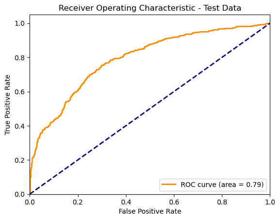

```python
# Get the predicted probabilities and labels for the test data
y_test_prob = classifier.predict_proba(X_test)[:, 1]
y_test_pred = classifier.predict(X_test)

# Compute ROC curve and ROC area for the test data
fpr_test, tpr_test, _ = roc_curve(y_test, y_test_prob)
roc_auc_test = auc(fpr_test, tpr_test)

# Plotting the ROC curve for the test data
plt.figure()
plt.plot(fpr_test, tpr_test, color='darkorange', lw=2,
         label='ROC curve (area = %0.2f)' % roc_auc_test)
plt.plot([0, 1], [0, 1], color='navy', lw=2, linestyle='--')
plt.xlim([0.0, 1.0])
plt.ylim([0.0, 1.05])
plt.xlabel('False Positive Rate')
plt.ylabel('True Positive Rate')
plt.title('Receiver Operating Characteristic - Test Data')
plt.legend(loc="lower right")
plt.show()
```

### Confusion Matrix for test data

```python
y_pred = classifier.predict_proba(X_test)[:,1]

predicted_class=np.zeros(y_pred.shape)
predicted_class[y_pred>0.5]=1

print(classification_report(y_test,predicted_class))
```

```
              precision    recall  f1-score   support

           0       0.85      0.96      0.91      2410
           1       0.69      0.33      0.44       590

    accuracy                           0.84      3000
   macro avg       0.77      0.65      0.67      3000
weighted avg       0.82      0.84      0.81      3000
```

Note: Threshold can be adjusted to maximize the sensitivity and specificity. Further the model performance can be improved by changing the parameter “hidden”.

#### Observation:

The overall model accuracy is 84%. The area under ROC curve is 0.79